# CODECHECK certificate 2024-019

# Summary

The reproduction of Figure 5 in the manuscript was achieved with help from the authors. This codecheck was done as part of the “CodeCheck goes NL” workshop in Erasmus University, Rotterdam, The Netherlands.

# CODECHECKER notes

The authors helped the codecheckers fix minor mistakes in the code involving paths to the data needed to generate the plot in Figure 5. The authors provided all the necessary code and data to perform the codecheck. These were obtained from https://osf.io/y2q3r/. The following changes were made to the code, Empatica.ipynb:

- Modified the `path` variable in the notebook’s second cell; its value was set to `<local-path>/osfstorage-archive/Raw Data/Empatica Avro Files`
- Modified the `events_path` variable the fourth cell; its value was set to `<local-path>/osfstorage-archive/Raw Data/" + pp + "_events.csv`

All the necessary libraries to run the notebooks, except for Jupyter itself, were obtained by installing the package as documented in the README file of the repository https://github.com/Aminsinichi/wearable-hrv.

## Recommendations

I suggest to the authors to consider the following suggestions for their next publication or workflow:

- Providing readers with jupyter notebooks that generate all the figures in the article. These notebooks can be submitted along with the article.
- Using the function `os.path.join` to handle the paths in Python code

# Manifest files

## Figure5.png

**Comment:** manuscript Figure 5

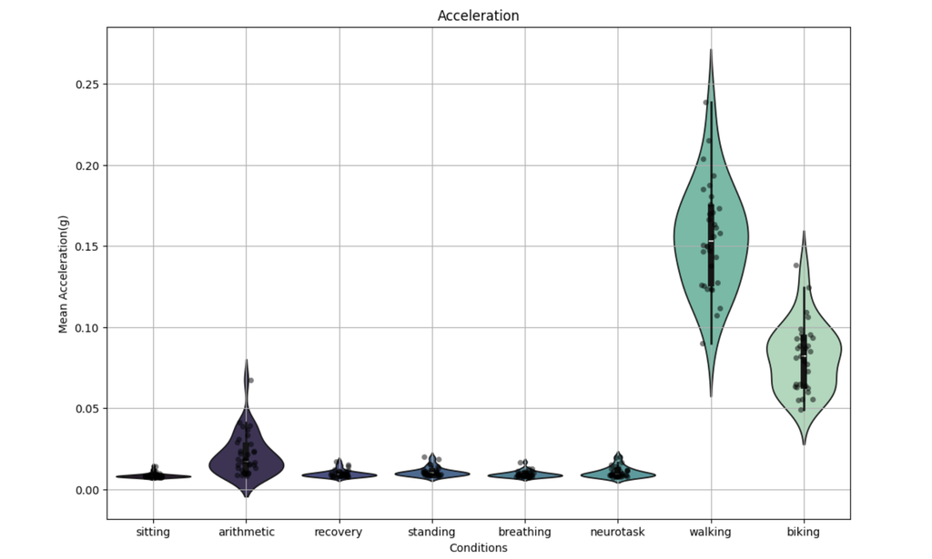

## Acknowledgements

I would like to thank Dr Bhatt and his team for promptly answering any queries I had with this reproduction. CODECHECK is financially supported by the Mozilla foundation.

# Citing this document

# About CODECHECK

This certificate confirms that the codecheckers could independently reproduce the results of a computational analysis given the data and code from a third party. A CODECHECK does not check whether the original computation analysis is correct. However, as all materials required for the reproduction are freely available by following the links in this document, the reader can then study for themselves the code and data.

# About this document

This document was created using [R Markdown](https://rmarkdown.rstudio.com/) using the [`codecheck`](https://github.com/codecheckers/codecheck) R package. `make codecheck.pdf` will regenerate the report file.